# Combining depRS and PRS for binary MDD

2025-03-12

This is an **updated script** for predicting *binary* lifetime MDD from depRS and PRS. depRS was trained on a *continuous* outcome - CBCL DSM5-oriented depression scores at year 2 from environmental factors at baseline. PRS were based on the MDD3 GWAS - we selected the threshold and timepoint with the best prediction. All continuous variables have been mean centred and standardised for comparison of effect sizes.

Similar analyses using the *cross-sectional* depRS model trained on *baseline CBCL* are in the file `envRS_PRS_main.Rmd`.

For (a) self-reported and (b) parent-reported lifetime MDD, we compare the following models:

Single predictor:  
(m1depRS) Y2 MDD ~ depRS  
(m1PRS) Y2 MDD ~ PRS

(m2) Y2 MDD ~ depRS + PRS  
(m3) Y2 MDD ~ depRS*PRS

```r
PRS = read.table("G://users/eileen/ABCD/ABCD_Environmental_Risk/ABCDv5.1/DATA/poppy_PRS/abcd_mdd3_prs_1024.t3.5.best", header = T) |> select(IID, PRS) |> mutate(across(where(is.numeric), scale))

depRS = readRDS("G://users/eileen/ABCD/ABCD_Environmental_Risk/ABCDv5.1/DATA/depRS_long.rds") |> select(src_subject_id, lambda.min)
names(depRS) = c("src_subject_id", "depRS")
depRS = depRS |>
  mutate(across(where(is.numeric), scale))

scores = merge(depRS, PRS, by.x = "src_subject_id", by.y = "IID")
```

depRS was available for N=7029 participants.  
PRS was available for N=4161 participants.

A total N=2979 participants had complete depRS and PRS data. Analyses will be conducted in this sample.

```r
rm(depRS, PRS)
```

# (a) Youth self-reported MDD

```r
mddy = readRDS("G://users/eileen/ABCD/ABCD_Environmental_Risk/ABCDv5.1/DATA/ksads_y.rds")

dat.y = merge(scores, mddy$y2, by = "src_subject_id")

dat.y |> summarise(
  N = n(),
  LifetimeMDD = sum(mdd_lifetime=="1"),
  LifetimeAny = sum(any_lifetime=="1")
) |> kbl(digits = 3)
```

| N | LifetimeMDD | LifetimeAny |
| --- | --- | --- |
| 2960 | 73 | 145 |

```r
prs_youth = dat.y |> select(src_subject_id, mdd_lifetime)
```

Of the N=2960 participants with self-reported MDD data at year 2, there were N=73 lifetime MDD cases. N=145 participants had a lifetime diagnosis of any depressive disorder (Major Depressive Disorder, Persistent Depressive Disorder (dysthymia), Depressive Disorder Unspecified).

## Model comparisons

```r
m1depRS = glm(mdd_lifetime ~ depRS, dat.y, family = binomial(link = "logit"))
m1PRS = glm(mdd_lifetime ~ PRS, dat.y, family = binomial(link = "logit"))

m2 = glm(mdd_lifetime ~ depRS + PRS,
         dat.y, family = binomial(link = "logit"))
m3 = glm(mdd_lifetime ~ depRS*PRS,
         dat.y, family = binomial(link = "logit"))
```

### ~ depRS

```r
test_performance(m1depRS, m2, m3) |> display(digits=3)
```

| Name | Model | BF | df | df_diff | Chi2 | p |
| --- | --- | --- | --- | --- | --- | --- |
| m1depRS | glm |  | 2 |  |  |  |
| m2 | glm | 0.130 | 3 | 1.000 | 3.909 | 0.048 |
| m3 | glm | 0.021 | 4 | 1.000 | 0.275 | 0.600 |

Models were detected as nested (in terms of fixed parameters) and are compared in sequential order.

### ~ PRS

```r
test_performance(m1PRS, m2, m3) |> display(digits=3)
```

| Name | Model | BF | df | df_diff | Chi2 | p |
| --- | --- | --- | --- | --- | --- | --- |
| m1PRS | glm |  | 2 |  |  |  |
| m2 | glm | > 1000 | 3 | 1.000 | 27.091 | < .001 |
| m3 | glm | 0.021 | 4 | 1.000 | 0.275 | 0.600 |

Models were detected as nested (in terms of fixed parameters) and are compared in sequential order.

## Performance metrics

```r
mods = list(m1depRS, m1PRS, m2, m3)

compare_performance(mods, verbose = F) |>
  mutate(Name = c("depRS", "PRS", "depRS+PRS", "depRS*PRS")) |>
  kable(digits = 3) |> kable_styling()
```

| Name | Model | AIC | AIC_wt | AICc | AICc_wt | BIC | BIC_wt | R2_Tjur | RMSE | Sigma | Log_loss | Score_log | Score_spherical | PCP |
| --- | --- | --- | --- | --- | --- | --- | --- | --- | --- | --- | --- | --- | --- | --- |
| depRS | glm | 659.319 | 0.213 | 659.323 | 0.214 | 671.305 | 0.883 | 0.013 | 0.154 | 1 | 0.111 | -1.818 | 0.016 | 0.953 |
| PRS | glm | 682.501 | 0.000 | 682.505 | 0.000 | 694.487 | 0.000 | 0.002 | 0.155 | 1 | 0.115 | -1.809 | 0.017 | 0.952 |
| depRS+PRS | glm | 657.410 | 0.553 | 657.418 | 0.553 | 675.389 | 0.115 | 0.014 | 0.154 | 1 | 0.110 | -1.819 | 0.016 | 0.953 |
| depRS*PRS | glm | 659.135 | 0.234 | 659.148 | 0.233 | 683.107 | 0.002 | 0.014 | 0.154 | 1 | 0.110 | -1.818 | 0.016 | 0.953 |

```r
lapply(mods, performance_accuracy) |>
  lapply(as.data.frame) |>
  bind_rows(.id = "model") |>
  mutate(model = c("depRS", "PRS", "depRS+PRS", "depRS*PRS")) |>
  kable(digits = 3) |> kable_styling()
```

| model | Accuracy | SE | CI | CI_low | CI_high | Method |
| --- | --- | --- | --- | --- | --- | --- |
| depRS | 0.669 | 0.076 | 0.95 | 0.564 | 0.753 | Area under Curve |
| PRS | 0.582 | 0.171 | 0.95 | 0.385 | 0.766 | Area under Curve |
| depRS+PRS | 0.691 | 0.120 | 0.95 | 0.553 | 0.785 | Area under Curve |
| depRS*PRS | 0.657 | 0.082 | 0.95 | 0.565 | 0.731 | Area under Curve |

## Model estimates

```r
sjPlot::tab_model(mods, dv.labels = c("depRS", "PRS", "depRS+PRS", "depRS*PRS"), collapse.ci = T, show.se = T, show.stat = T)
```

|  | depRS |  |  |  | PRS |  |  |  | depRS+PRS |  |  |  | depRS*PRS |  |  |  |
| --- | --- | --- | --- | --- | --- | --- | --- | --- | --- | --- | --- | --- | --- | --- | --- | --- |
| Predictors | Odds Ratios | std. Error | Statistic | p | Odds Ratios | std. Error | Statistic | p | Odds Ratios | std. Error | Statistic | p | Odds Ratios | std. Error | Statistic | p |
| (Intercept) | 0.02 (0.02 – 0.03) | 0.00 | -29.04 | **<0.001** | 0.02 (0.02 – 0.03) | 0.00 | -30.20 | **<0.001** | 0.02 (0.02 – 0.03) | 0.00 | -28.58 | **<0.001** | 0.02 (0.02 – 0.03) | 0.00 | -28.35 | **<0.001** |
| depRS | 1.73 (1.43 – 2.07) | 0.16 | 5.87 | **<0.001** |  |  |  |  | 1.70 (1.40 – 2.03) | 0.16 | 5.61 | **<0.001** | 1.72 (1.41 – 2.08) | 0.17 | 5.53 | **<0.001** |
| PRS |  |  |  |  | 1.35 (1.07 – 1.70) | 0.16 | 2.49 | **0.013** | 1.27 (1.00 – 1.61) | 0.15 | 1.97 | **0.049** | 1.31 (1.01 – 1.70) | 0.17 | 2.01 | **0.044** |
| depRS × PRS |  |  |  |  |  |  |  |  |  |  |  |  | 0.95 (0.78 – 1.15) | 0.10 | -0.52 | 0.601 |
| Observations | 2960 |  |  |  | 2960 |  |  |  | 2960 |  |  |  | 2960 |  |  |  |
| R<sup>2</sup> Tjur | 0.013 |  |  |  | 0.002 |  |  |  | 0.014 |  |  |  | 0.014 |  |  |  |

## ROC curves

```r
#ROC curves for each model
dat.y = dat.y |> mutate(
  m1depRS = m1depRS$fitted.values,
  m1PRS = m1PRS$fitted.values,
  m2 = m2$fitted.values,
  m3 = m3$fitted.values
)

mods = c("m1depRS", "m1PRS", "m2", "m3")

rocs.y = list()
for (m in 1:length(mods)) {
  out = roc(dat.y$mdd_lifetime, dat.y[,mods[m]],
            ci = TRUE, auc = TRUE)
  rocs.y[[mods[m]]] = out
}
```

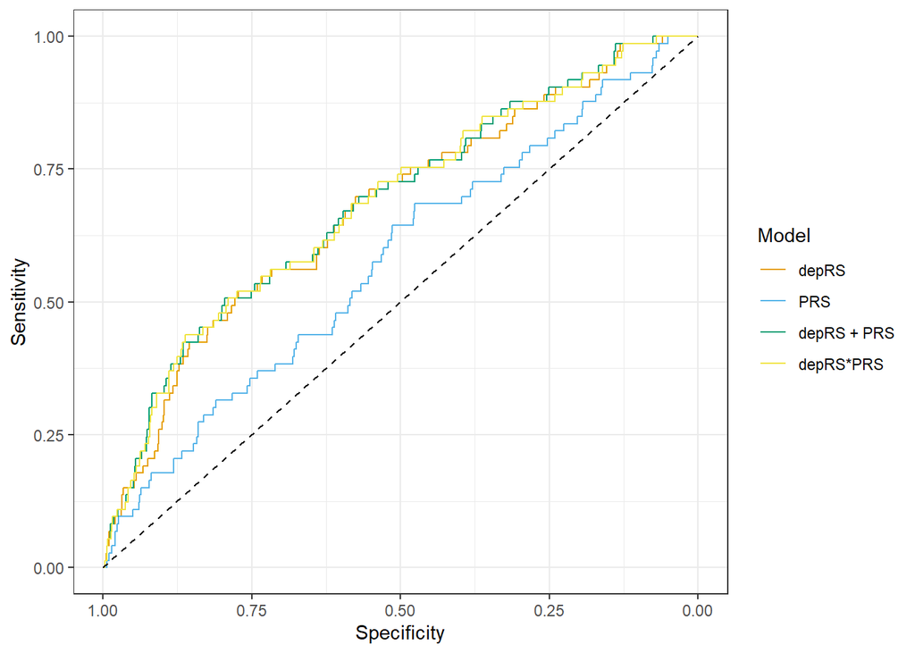

```r
youth = ggroc(list("depRS" = rocs.y$m1depRS, "PRS" = rocs.y$m1PRS, "depRS + PRS" = rocs.y$m2, "depRS*PRS" = rocs.y$m3)) +
  scale_color_manual(values = pal) +
  geom_segment(aes(x=1, y=0, xend=0, yend=1), colour = "black", alpha = 0.7, linetype = "dashed") +
  theme_bw() +
  labs(x = "Specificity", y = "Sensitivity", color = "Model")

youth
```

```r
par("din")
```

[1] 6.999999 4.999999

```r
#ggsave("C://Users/eilee/Desktop/PhD/Year 3/Drafts/envRS_paper/Figures/ROC_youth.png", youth, device = "png", create.dir = TRUE, width = 6, height = 4, units = "in")
```

# (b) Parent-reported MDD

```r
mddp = readRDS("G://users/eileen/ABCD/ABCD_Environmental_Risk/ABCDv5.1/DATA/ksads_p.rds")

dat.p = merge(scores, mddp$y2, by = "src_subject_id")

dat.p |> summarise(
  N = n(),
  LifetimeMDD = sum(mdd_lifetime=="1"),
  LifetimeAny = sum(any_lifetime=="1")
) |> kbl(digits = 3)
```

| N | LifetimeMDD | LifetimeAny |
| --- | --- | --- |
| 2948 | 118 | 251 |

```r
prs_parent = dat.p |> select(src_subject_id, mdd_lifetime)
```

## Model comparisons

```r
m1depRS = glm(mdd_lifetime ~ depRS, dat.p, family = binomial(link = "logit"))
m1PRS = glm(mdd_lifetime ~ PRS, dat.p, family = binomial(link = "logit"))

m2 = glm(mdd_lifetime ~ depRS + PRS,
         dat.p, family = binomial(link = "logit"))
m3 = glm(mdd_lifetime ~ depRS*PRS,
         dat.p, family = binomial(link = "logit"))
```

### ~ depRS

```r
test_performance(m1depRS, m2, m3) |> display(digits=3)
```

| Name | Model | BF | df | df_diff | Chi2 | p |
| --- | --- | --- | --- | --- | --- | --- |
| m1depRS | glm |  | 2 |  |  |  |
| m2 | glm | 0.129 | 3 | 1.000 | 3.899 | 0.048 |
| m3 | glm | 0.020 | 4 | 1.000 | 0.201 | 0.654 |

Models were detected as nested (in terms of fixed parameters) and are compared in sequential order.

### ~ PRS

```r
test_performance(m1PRS, m2, m3) |> display(digits=3)
```

| Name | Model | BF | df | df_diff | Chi2 | p |
| --- | --- | --- | --- | --- | --- | --- |
| m1PRS | glm |  | 2 |  |  |  |
| m2 | glm | > 1000 | 3 | 1.000 | 61.955 | < .001 |
| m3 | glm | 0.020 | 4 | 1.000 | 0.201 | 0.654 |

Models were detected as nested (in terms of fixed parameters) and are compared in sequential order.

## Performance metrics

```r
mods = list(m1depRS, m1PRS, m2, m3)

compare_performance(mods, verbose = F) |>
  mutate(Name = c("depRS", "PRS", "depRS+PRS", "depRS*PRS")) |>
  kable(digits = 3) |> kable_styling()
```

| Name | Model | AIC | AIC_wt | AICc | AICc_wt | BIC | BIC_wt | R2_Tjur | RMSE | Sigma | Log_loss | Score_log | Score_spherical | PCP |
| --- | --- | --- | --- | --- | --- | --- | --- | --- | --- | --- | --- | --- | --- | --- |
| depRS | glm | 928.707 | 0.216 | 928.711 | 0.216 | 940.684 | 0.883 | 0.033 | 0.193 | 1 | 0.157 | -4.845 | 0.013 | 0.926 |
| PRS | glm | 986.763 | 0.000 | 986.767 | 0.000 | 998.740 | 0.000 | 0.003 | 0.196 | 1 | 0.167 | -4.762 | 0.012 | 0.923 |
| depRS+PRS | glm | 926.808 | 0.557 | 926.816 | 0.558 | 944.775 | 0.114 | 0.035 | 0.193 | 1 | 0.156 | -4.850 | 0.012 | 0.926 |
| depRS*PRS | glm | 928.607 | 0.227 | 928.621 | 0.226 | 952.562 | 0.002 | 0.034 | 0.193 | 1 | 0.156 | -4.847 | 0.012 | 0.926 |

```r
lapply(mods, performance_accuracy) |>
  lapply(as.data.frame) |>
  bind_rows(.id = "model") |>
  mutate(model = c("depRS", "PRS", "depRS+PRS", "depRS*PRS")) |>
  kable(digits = 3) |> kable_styling()
```

| model | Accuracy | SE | CI | CI_low | CI_high | Method |
| --- | --- | --- | --- | --- | --- | --- |
| depRS | 0.701 | 0.043 | 0.95 | 0.651 | 0.758 | Area under Curve |
| PRS | 0.566 | 0.036 | 0.95 | 0.519 | 0.607 | Area under Curve |
| depRS+PRS | 0.701 | 0.034 | 0.95 | 0.657 | 0.739 | Area under Curve |
| depRS*PRS | 0.704 | 0.022 | 0.95 | 0.677 | 0.729 | Area under Curve |

## Model estimates

```r
sjPlot::tab_model(mods, dv.labels = c("depRS", "PRS", "depRS+PRS", "depRS*PRS"), collapse.ci = T, show.se = T, show.stat = T)
```

|  | depRS |  |  |  | PRS |  |  |  | depRS+PRS |  |  |  | depRS*PRS |  |  |  |
| --- | --- | --- | --- | --- | --- | --- | --- | --- | --- | --- | --- | --- | --- | --- | --- | --- |
| Predictors | Odds Ratios | std. Error | Statistic | p | Odds Ratios | std. Error | Statistic | p | Odds Ratios | std. Error | Statistic | p | Odds Ratios | std. Error | Statistic | p |
| (Intercept) | 0.03 (0.03 – 0.04) | 0.00 | -31.31 | **<0.001** | 0.04 (0.03 – 0.05) | 0.00 | -33.17 | **<0.001** | 0.03 (0.03 – 0.04) | 0.00 | -31.04 | **<0.001** | 0.03 (0.03 – 0.04) | 0.00 | -30.88 | **<0.001** |
| depRS | 1.91 (1.65 – 2.22) | 0.14 | 8.60 | **<0.001** |  |  |  |  | 1.88 (1.62 – 2.19) | 0.14 | 8.31 | **<0.001** | 1.90 (1.63 – 2.22) | 0.15 | 8.14 | **<0.001** |
| PRS |  |  |  |  | 1.31 (1.08 – 1.57) | 0.12 | 2.81 | **0.005** | 1.21 (1.00 – 1.46) | 0.12 | 1.97 | **0.049** | 1.24 (1.00 – 1.53) | 0.13 | 1.96 | 0.050 |
| depRS × PRS |  |  |  |  |  |  |  |  |  |  |  |  | 0.97 (0.83 – 1.13) | 0.08 | -0.45 | 0.654 |
| Observations | 2948 |  |  |  | 2948 |  |  |  | 2948 |  |  |  | 2948 |  |  |  |
| R<sup>2</sup> Tjur | 0.033 |  |  |  | 0.003 |  |  |  | 0.035 |  |  |  | 0.034 |  |  |  |

## ROC curves

```r
#ROC curves for each model
dat.p = dat.p |> mutate(
  m1depRS = m1depRS$fitted.values,
  m1PRS = m1PRS$fitted.values,
  m2 = m2$fitted.values,
  m3 = m3$fitted.values
)

mods = c("m1depRS", "m1PRS", "m2", "m3")

rocs.p = list()
for (m in 1:length(mods)) {
  out = roc(dat.p$mdd_lifetime, dat.p[,mods[m]],
            ci = TRUE, auc = TRUE)
  rocs.p[[mods[m]]] = out
}
```

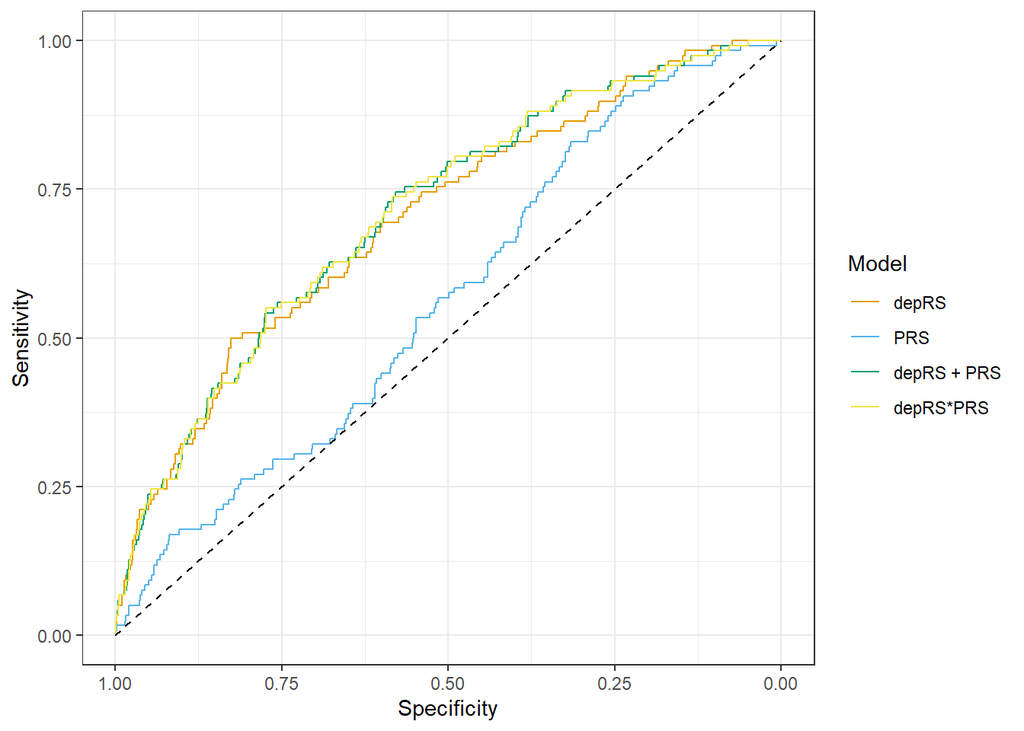

```r
parent = ggroc(list("depRS" = rocs.p$m1depRS, "PRS" = rocs.p$m1PRS, "depRS + PRS" = rocs.p$m2, "depRS*PRS" = rocs.p$m3)) +
  scale_color_manual(values = pal) +
  geom_segment(aes(x=1, y=0, xend=0, yend=1), colour = "black", alpha = 0.7, linetype = "dashed") +
  theme_bw() +
  labs(x = "Specificity", y = "Sensitivity", color = "Model")

parent
```

```r
#ggsave("C://Users/eilee/Desktop/PhD/Year 3/Drafts/envRS_paper/Figures/ROC_parent.png", parent, device = "png", create.dir = TRUE, width = 6, height = 4, units = "in")
```

## ROC figure

```r
library(patchwork)

ptch_plot = parent + theme(legend.position = "none") + ggtitle("(A)") | youth + ggtitle("(B)")
```

```r
#ggsave("C://Users/eilee/Desktop/PhD/Year 3/Drafts/envRS_paper/Figures/ROC_fig.png", ptch_plot, device = "png", create.dir = TRUE, width = 9, height = 4, units = "in")
```

# Descriptives

## youth

```r
y.dat = readRDS("G://users/eileen/ABCD/ABCD_Environmental_Risk/ABCDv5.1/DATA/predictors_unrelatedIDs.rds") |> filter(src_subject_id %in% prs_youth$src_subject_id) |> select(src_subject_id, eventname, interview_age, gender_id, birthsex, race_ethnicity, income, parent_ed)

y2age = y.dat |> filter(eventname == "2_year_follow_up_y_arm_1") |> mutate(y2_age = interview_age/12) |> select(src_subject_id, y2_age)
y.base = y.dat |> filter(eventname=="baseline_year_1_arm_1") |> mutate(age_yrs = interview_age/12)

prs_youth = merge(prs_youth, y2age)
prs_youth = merge(prs_youth, y.base)
```

### all

```r
summarytools::dfSummary(prs_youth[,-1],plain.ascii = F, style = "grid", valid.col = F, graph.col = T, varnumbers = F, tmp.img.dir = "/tmp", max.tbl.height = 300) |> print(method = "render")
```

NA

prs_youth

**Dimensions**: 2960 x 10  
**Duplicates**: 724

| **Variable** | **Stats / Values** | **Freqs (% of Valid)** | **Graph** | **Missing** |
| --- | --- | --- | --- | --- |
| mdd_lifetime [factor] | 1. 0 2. 1 | 2887 ( 97.5% ) 73 ( 2.5% ) |  | 0 (0.0%) |
| y2_age [numeric] | Mean (sd) : 12 (0.7) min ≤ med ≤ max: 10.8 ≤ 12 ≤ 13.8 IQR (CV) : 1 (0.1) | 38 distinct values |  | 0 (0.0%) |
| eventname [factor] | 1. 1_year_follow_up_y_arm_1 2. 2_year_follow_up_y_arm_1 3. 3_year_follow_up_y_arm_1 4. 4_year_follow_up_y_arm_1 5. baseline_year_1_arm_1 | 0 ( 0.0% ) 0 ( 0.0% ) 0 ( 0.0% ) 0 ( 0.0% ) 2960 ( 100.0% ) |  | 0 (0.0%) |
| interview_age [integer] | Mean (sd) : 119 (7.4) min ≤ med ≤ max: 107 ≤ 119 ≤ 132 IQR (CV) : 13 (0.1) | 26 distinct values |  | 0 (0.0%) |
| gender_id [factor] | 1. M 2. F 3. Mtrans 4. Ftrans 5. GNC 6. Diff | 1607 ( 54.3% ) 1352 ( 45.7% ) 0 ( 0.0% ) 1 ( 0.0% ) 0 ( 0.0% ) 0 ( 0.0% ) |  | 0 (0.0%) |
| birthsex [factor] | 1. M 2. F 3. Intersex | 1607 ( 54.3% ) 1353 ( 45.7% ) 0 ( 0.0% ) |  | 0 (0.0%) |
| race_ethnicity [factor] | 1. White 2. Black 3. Hispanic 4. Asian 5. Other | 2960 ( 100.0% ) 0 ( 0.0% ) 0 ( 0.0% ) 0 ( 0.0% ) 0 ( 0.0% ) |  | 0 (0.0%) |
| income [integer] | Mean (sd) : 8.2 (1.6) min ≤ med ≤ max: 1 ≤ 9 ≤ 10 IQR (CV) : 2 (0.2) | 1 : 16 ( 0.5% ) 2 : 23 ( 0.8% ) 3 : 15 ( 0.5% ) 4 : 32 ( 1.1% ) 5 : 84 ( 2.8% ) 6 : 159 ( 5.4% ) 7 : 428 ( 14.5% ) 8 : 525 ( 17.7% ) 9 : 1229 ( 41.5% ) 10 : 449 ( 15.2% ) |  | 0 (0.0%) |
| parent_ed [factor] | 1. Bachelor 2. HS/GED 3. less_HS 4. Postgraduate 5. Some_College | 1097 ( 37.1% ) 128 ( 4.3% ) 18 ( 0.6% ) 1017 ( 34.4% ) 700 ( 23.6% ) |  | 0 (0.0%) |
| age_yrs [numeric] | Mean (sd) : 9.9 (0.6) min ≤ med ≤ max: 8.9 ≤ 9.9 ≤ 11 IQR (CV) : 1.1 (0.1) | 26 distinct values |  | 0 (0.0%) |

Generated by summarytools 1.0.1 ([R](https://www.r-project.org/) version 4.4.1)  
2025-03-12

### case

```r
prs_youth[,-1] |> filter(mdd_lifetime==1) |>
summarytools::dfSummary(plain.ascii = F, style = "grid", valid.col = F, graph.col = T, varnumbers = F, tmp.img.dir = "/tmp", max.tbl.height = 300) |> print(method = "render")
```

NA

**Dimensions**: 73 x 10  
**Duplicates**: 0

| **Variable** | **Stats / Values** | **Freqs (% of Valid)** | **Graph** | **Missing** |
| --- | --- | --- | --- | --- |
| mdd_lifetime [factor] | 1. 0 2. 1 | 0 ( 0.0% ) 73 ( 100.0% ) |  | 0 (0.0%) |
| y2_age [numeric] | Mean (sd) : 12.2 (0.8) min ≤ med ≤ max: 10.8 ≤ 12.1 ≤ 13.7 IQR (CV) : 1.3 (0.1) | 32 distinct values |  | 0 (0.0%) |
| eventname [factor] | 1. 1_year_follow_up_y_arm_1 2. 2_year_follow_up_y_arm_1 3. 3_year_follow_up_y_arm_1 4. 4_year_follow_up_y_arm_1 5. baseline_year_1_arm_1 | 0 ( 0.0% ) 0 ( 0.0% ) 0 ( 0.0% ) 0 ( 0.0% ) 73 ( 100.0% ) |  | 0 (0.0%) |
| interview_age [integer] | Mean (sd) : 119.4 (8.2) min ≤ med ≤ max: 107 ≤ 119 ≤ 132 IQR (CV) : 17 (0.1) | 26 distinct values |  | 0 (0.0%) |
| gender_id [factor] | 1. M 2. F 3. Mtrans 4. Ftrans 5. GNC 6. Diff | 31 ( 42.5% ) 42 ( 57.5% ) 0 ( 0.0% ) 0 ( 0.0% ) 0 ( 0.0% ) 0 ( 0.0% ) |  | 0 (0.0%) |
| birthsex [factor] | 1. M 2. F 3. Intersex | 30 ( 41.1% ) 43 ( 58.9% ) 0 ( 0.0% ) |  | 0 (0.0%) |
| race_ethnicity [factor] | 1. White 2. Black 3. Hispanic 4. Asian 5. Other | 73 ( 100.0% ) 0 ( 0.0% ) 0 ( 0.0% ) 0 ( 0.0% ) 0 ( 0.0% ) |  | 0 (0.0%) |
| income [integer] | Mean (sd) : 7.4 (1.9) min ≤ med ≤ max: 1 ≤ 7 ≤ 10 IQR (CV) : 2 (0.3) | 1 : 1 ( 1.4% ) 2 : 2 ( 2.7% ) 4 : 2 ( 2.7% ) 5 : 3 ( 4.1% ) 6 : 7 ( 9.6% ) 7 : 24 ( 32.9% ) 8 : 9 ( 12.3% ) 9 : 17 ( 23.3% ) 10 : 8 ( 11.0% ) |  | 0 (0.0%) |
| parent_ed [factor] | 1. Bachelor 2. HS/GED 3. less_HS 4. Postgraduate 5. Some_College | 23 ( 31.5% ) 3 ( 4.1% ) 1 ( 1.4% ) 14 ( 19.2% ) 32 ( 43.8% ) |  | 0 (0.0%) |
| age_yrs [numeric] | Mean (sd) : 9.9 (0.7) min ≤ med ≤ max: 8.9 ≤ 9.9 ≤ 11 IQR (CV) : 1.4 (0.1) | 26 distinct values |  | 0 (0.0%) |

Generated by summarytools 1.0.1 ([R](https://www.r-project.org/) version 4.4.1)  
2025-03-12

### control

```r
prs_youth[,-1] |> filter(mdd_lifetime==0) |>
summarytools::dfSummary(plain.ascii = F, style = "grid", valid.col = F, graph.col = T, varnumbers = F, tmp.img.dir = "/tmp", max.tbl.height = 300) |> print(method = "render")
```

NA

**Dimensions**: 2887 x 10  
**Duplicates**: 724

| **Variable** | **Stats / Values** | **Freqs (% of Valid)** | **Graph** | **Missing** |
| --- | --- | --- | --- | --- |
| mdd_lifetime [factor] | 1. 0 2. 1 | 2887 ( 100.0% ) 0 ( 0.0% ) |  | 0 (0.0%) |
| y2_age [numeric] | Mean (sd) : 12 (0.7) min ≤ med ≤ max: 10.8 ≤ 12 ≤ 13.8 IQR (CV) : 1 (0.1) | 38 distinct values |  | 0 (0.0%) |
| eventname [factor] | 1. 1_year_follow_up_y_arm_1 2. 2_year_follow_up_y_arm_1 3. 3_year_follow_up_y_arm_1 4. 4_year_follow_up_y_arm_1 5. baseline_year_1_arm_1 | 0 ( 0.0% ) 0 ( 0.0% ) 0 ( 0.0% ) 0 ( 0.0% ) 2887 ( 100.0% ) |  | 0 (0.0%) |
| interview_age [integer] | Mean (sd) : 119 (7.4) min ≤ med ≤ max: 107 ≤ 119 ≤ 132 IQR (CV) : 13 (0.1) | 26 distinct values |  | 0 (0.0%) |
| gender_id [factor] | 1. M 2. F 3. Mtrans 4. Ftrans 5. GNC 6. Diff | 1576 ( 54.6% ) 1310 ( 45.4% ) 0 ( 0.0% ) 1 ( 0.0% ) 0 ( 0.0% ) 0 ( 0.0% ) |  | 0 (0.0%) |
| birthsex [factor] | 1. M 2. F 3. Intersex | 1577 ( 54.6% ) 1310 ( 45.4% ) 0 ( 0.0% ) |  | 0 (0.0%) |
| race_ethnicity [factor] | 1. White 2. Black 3. Hispanic 4. Asian 5. Other | 2887 ( 100.0% ) 0 ( 0.0% ) 0 ( 0.0% ) 0 ( 0.0% ) 0 ( 0.0% ) |  | 0 (0.0%) |
| income [integer] | Mean (sd) : 8.2 (1.5) min ≤ med ≤ max: 1 ≤ 9 ≤ 10 IQR (CV) : 1 (0.2) | 1 : 15 ( 0.5% ) 2 : 21 ( 0.7% ) 3 : 15 ( 0.5% ) 4 : 30 ( 1.0% ) 5 : 81 ( 2.8% ) 6 : 152 ( 5.3% ) 7 : 404 ( 14.0% ) 8 : 516 ( 17.9% ) 9 : 1212 ( 42.0% ) 10 : 441 ( 15.3% ) |  | 0 (0.0%) |
| parent_ed [factor] | 1. Bachelor 2. HS/GED 3. less_HS 4. Postgraduate 5. Some_College | 1074 ( 37.2% ) 125 ( 4.3% ) 17 ( 0.6% ) 1003 ( 34.7% ) 668 ( 23.1% ) |  | 0 (0.0%) |
| age_yrs [numeric] | Mean (sd) : 9.9 (0.6) min ≤ med ≤ max: 8.9 ≤ 9.9 ≤ 11 IQR (CV) : 1.1 (0.1) | 26 distinct values |  | 0 (0.0%) |

Generated by summarytools 1.0.1 ([R](https://www.r-project.org/) version 4.4.1)  
2025-03-12

## parent

```r
p.dat = readRDS("G://users/eileen/ABCD/ABCD_Environmental_Risk/ABCDv5.1/DATA/predictors_unrelatedIDs.rds") |> filter(src_subject_id %in% prs_parent$src_subject_id) |> select(src_subject_id, eventname, interview_age, gender_id, birthsex, race_ethnicity, income, parent_ed)

y2age = p.dat |> filter(eventname == "2_year_follow_up_y_arm_1") |> mutate(y2_age = interview_age/12) |> select(src_subject_id, y2_age)
p.base = p.dat |> filter(eventname=="baseline_year_1_arm_1") |> mutate(age_yrs = interview_age/12)

prs_parent = merge(prs_parent, y2age)
prs_parent = merge(prs_parent, p.base)
```

### all

```r
summarytools::dfSummary(prs_parent[,-1],plain.ascii = F, style = "grid", valid.col = F, graph.col = T, varnumbers = F, tmp.img.dir = "/tmp", max.tbl.height = 300) |> print(method = "render")
```

NA

prs_parent

**Dimensions**: 2948 x 10  
**Duplicates**: 702

| **Variable** | **Stats / Values** | **Freqs (% of Valid)** | **Graph** | **Missing** |
| --- | --- | --- | --- | --- |
| mdd_lifetime [factor] | 1. 0 2. 1 | 2830 ( 96.0% ) 118 ( 4.0% ) |  | 0 (0.0%) |
| y2_age [numeric] | Mean (sd) : 12 (0.7) min ≤ med ≤ max: 10.8 ≤ 12 ≤ 13.8 IQR (CV) : 1 (0.1) | 38 distinct values |  | 0 (0.0%) |
| eventname [factor] | 1. 1_year_follow_up_y_arm_1 2. 2_year_follow_up_y_arm_1 3. 3_year_follow_up_y_arm_1 4. 4_year_follow_up_y_arm_1 5. baseline_year_1_arm_1 | 0 ( 0.0% ) 0 ( 0.0% ) 0 ( 0.0% ) 0 ( 0.0% ) 2948 ( 100.0% ) |  | 0 (0.0%) |
| interview_age [integer] | Mean (sd) : 119 (7.4) min ≤ med ≤ max: 107 ≤ 119 ≤ 132 IQR (CV) : 13 (0.1) | 26 distinct values |  | 0 (0.0%) |
| gender_id [factor] | 1. M 2. F 3. Mtrans 4. Ftrans 5. GNC 6. Diff | 1594 ( 54.1% ) 1353 ( 45.9% ) 0 ( 0.0% ) 1 ( 0.0% ) 0 ( 0.0% ) 0 ( 0.0% ) |  | 0 (0.0%) |
| birthsex [factor] | 1. M 2. F 3. Intersex | 1594 ( 54.1% ) 1354 ( 45.9% ) 0 ( 0.0% ) |  | 0 (0.0%) |
| race_ethnicity [factor] | 1. White 2. Black 3. Hispanic 4. Asian 5. Other | 2948 ( 100.0% ) 0 ( 0.0% ) 0 ( 0.0% ) 0 ( 0.0% ) 0 ( 0.0% ) |  | 0 (0.0%) |
| income [integer] | Mean (sd) : 8.2 (1.6) min ≤ med ≤ max: 1 ≤ 9 ≤ 10 IQR (CV) : 2 (0.2) | 1 : 16 ( 0.5% ) 2 : 23 ( 0.8% ) 3 : 14 ( 0.5% ) 4 : 32 ( 1.1% ) 5 : 83 ( 2.8% ) 6 : 159 ( 5.4% ) 7 : 427 ( 14.5% ) 8 : 526 ( 17.8% ) 9 : 1223 ( 41.5% ) 10 : 445 ( 15.1% ) |  | 0 (0.0%) |
| parent_ed [factor] | 1. Bachelor 2. HS/GED 3. less_HS 4. Postgraduate 5. Some_College | 1092 ( 37.0% ) 127 ( 4.3% ) 18 ( 0.6% ) 1013 ( 34.4% ) 698 ( 23.7% ) |  | 0 (0.0%) |
| age_yrs [numeric] | Mean (sd) : 9.9 (0.6) min ≤ med ≤ max: 8.9 ≤ 9.9 ≤ 11 IQR (CV) : 1.1 (0.1) | 26 distinct values |  | 0 (0.0%) |

Generated by summarytools 1.0.1 ([R](https://www.r-project.org/) version 4.4.1)  
2025-03-12

### case

```r
prs_parent[,-1] |> filter(mdd_lifetime==1) |>
summarytools::dfSummary(plain.ascii = F, style = "grid", valid.col = F, graph.col = T, varnumbers = F, tmp.img.dir = "/tmp", max.tbl.height = 300) |> print(method = "render")
```

NA

**Dimensions**: 118 x 10  
**Duplicates**: 0

| **Variable** | **Stats / Values** | **Freqs (% of Valid)** | **Graph** | **Missing** |
| --- | --- | --- | --- | --- |
| mdd_lifetime [factor] | 1. 0 2. 1 | 0 ( 0.0% ) 118 ( 100.0% ) |  | 0 (0.0%) |
| y2_age [numeric] | Mean (sd) : 12.2 (0.7) min ≤ med ≤ max: 10.8 ≤ 12.3 ≤ 13.7 IQR (CV) : 1.2 (0.1) | 34 distinct values |  | 0 (0.0%) |
| eventname [factor] | 1. 1_year_follow_up_y_arm_1 2. 2_year_follow_up_y_arm_1 3. 3_year_follow_up_y_arm_1 4. 4_year_follow_up_y_arm_1 5. baseline_year_1_arm_1 | 0 ( 0.0% ) 0 ( 0.0% ) 0 ( 0.0% ) 0 ( 0.0% ) 118 ( 100.0% ) |  | 0 (0.0%) |
| interview_age [integer] | Mean (sd) : 120.7 (7.8) min ≤ med ≤ max: 107 ≤ 122 ≤ 131 IQR (CV) : 14 (0.1) | 25 distinct values |  | 0 (0.0%) |
| gender_id [factor] | 1. M 2. F 3. Mtrans 4. Ftrans 5. GNC 6. Diff | 57 ( 48.3% ) 61 ( 51.7% ) 0 ( 0.0% ) 0 ( 0.0% ) 0 ( 0.0% ) 0 ( 0.0% ) |  | 0 (0.0%) |
| birthsex [factor] | 1. M 2. F 3. Intersex | 57 ( 48.3% ) 61 ( 51.7% ) 0 ( 0.0% ) |  | 0 (0.0%) |
| race_ethnicity [factor] | 1. White 2. Black 3. Hispanic 4. Asian 5. Other | 118 ( 100.0% ) 0 ( 0.0% ) 0 ( 0.0% ) 0 ( 0.0% ) 0 ( 0.0% ) |  | 0 (0.0%) |
| income [integer] | Mean (sd) : 7.7 (1.7) min ≤ med ≤ max: 1 ≤ 8 ≤ 10 IQR (CV) : 2 (0.2) | 1 : 1 ( 0.8% ) 3 : 1 ( 0.8% ) 4 : 4 ( 3.4% ) 5 : 6 ( 5.1% ) 6 : 17 ( 14.4% ) 7 : 16 ( 13.6% ) 8 : 21 ( 17.8% ) 9 : 42 ( 35.6% ) 10 : 10 ( 8.5% ) |  | 0 (0.0%) |
| parent_ed [factor] | 1. Bachelor 2. HS/GED 3. less_HS 4. Postgraduate 5. Some_College | 36 ( 30.5% ) 5 ( 4.2% ) 0 ( 0.0% ) 36 ( 30.5% ) 41 ( 34.7% ) |  | 0 (0.0%) |
| age_yrs [numeric] | Mean (sd) : 10.1 (0.6) min ≤ med ≤ max: 8.9 ≤ 10.2 ≤ 10.9 IQR (CV) : 1.2 (0.1) | 25 distinct values |  | 0 (0.0%) |

Generated by summarytools 1.0.1 ([R](https://www.r-project.org/) version 4.4.1)  
2025-03-12

### control

```r
prs_parent[,-1] |> filter(mdd_lifetime==0) |>
summarytools::dfSummary(plain.ascii = F, style = "grid", valid.col = F, graph.col = T, varnumbers = F, tmp.img.dir = "/tmp", max.tbl.height = 300) |> print(method = "render")
```

NA

**Dimensions**: 2830 x 10  
**Duplicates**: 702

| **Variable** | **Stats / Values** | **Freqs (% of Valid)** | **Graph** | **Missing** |
| --- | --- | --- | --- | --- |
| mdd_lifetime [factor] | 1. 0 2. 1 | 2830 ( 100.0% ) 0 ( 0.0% ) |  | 0 (0.0%) |
| y2_age [numeric] | Mean (sd) : 12 (0.7) min ≤ med ≤ max: 10.8 ≤ 12 ≤ 13.8 IQR (CV) : 1 (0.1) | 38 distinct values |  | 0 (0.0%) |
| eventname [factor] | 1. 1_year_follow_up_y_arm_1 2. 2_year_follow_up_y_arm_1 3. 3_year_follow_up_y_arm_1 4. 4_year_follow_up_y_arm_1 5. baseline_year_1_arm_1 | 0 ( 0.0% ) 0 ( 0.0% ) 0 ( 0.0% ) 0 ( 0.0% ) 2830 ( 100.0% ) |  | 0 (0.0%) |
| interview_age [integer] | Mean (sd) : 118.9 (7.3) min ≤ med ≤ max: 107 ≤ 119 ≤ 132 IQR (CV) : 13 (0.1) | 26 distinct values |  | 0 (0.0%) |
| gender_id [factor] | 1. M 2. F 3. Mtrans 4. Ftrans 5. GNC 6. Diff | 1537 ( 54.3% ) 1292 ( 45.7% ) 0 ( 0.0% ) 1 ( 0.0% ) 0 ( 0.0% ) 0 ( 0.0% ) |  | 0 (0.0%) |
| birthsex [factor] | 1. M 2. F 3. Intersex | 1537 ( 54.3% ) 1293 ( 45.7% ) 0 ( 0.0% ) |  | 0 (0.0%) |
| race_ethnicity [factor] | 1. White 2. Black 3. Hispanic 4. Asian 5. Other | 2830 ( 100.0% ) 0 ( 0.0% ) 0 ( 0.0% ) 0 ( 0.0% ) 0 ( 0.0% ) |  | 0 (0.0%) |
| income [integer] | Mean (sd) : 8.2 (1.5) min ≤ med ≤ max: 1 ≤ 9 ≤ 10 IQR (CV) : 2 (0.2) | 1 : 15 ( 0.5% ) 2 : 23 ( 0.8% ) 3 : 13 ( 0.5% ) 4 : 28 ( 1.0% ) 5 : 77 ( 2.7% ) 6 : 142 ( 5.0% ) 7 : 411 ( 14.5% ) 8 : 505 ( 17.8% ) 9 : 1181 ( 41.7% ) 10 : 435 ( 15.4% ) |  | 0 (0.0%) |
| parent_ed [factor] | 1. Bachelor 2. HS/GED 3. less_HS 4. Postgraduate 5. Some_College | 1056 ( 37.3% ) 122 ( 4.3% ) 18 ( 0.6% ) 977 ( 34.5% ) 657 ( 23.2% ) |  | 0 (0.0%) |
| age_yrs [numeric] | Mean (sd) : 9.9 (0.6) min ≤ med ≤ max: 8.9 ≤ 9.9 ≤ 11 IQR (CV) : 1.1 (0.1) | 26 distinct values |  | 0 (0.0%) |

Generated by summarytools 1.0.1 ([R](https://www.r-project.org/) version 4.4.1)  
2025-03-12